# Week2

Sarfaraz Ahmed

July 26, 2017

# Pre-Lab 2: Bull Rider Data

[figure not shown]

Over 1,200 bull riders from around the world are members of Professional Bull Riders (PBR) and compete in the more than 300 PBR affiliated bull riding events per year. This data set includes information about the top 50 ranked bull riders for the 2013, according to the PBR standings reported in July of 2013. Rankings are based on a system which awards points for qualified rides at events throughout the season.

Primary Research Question

The average American adult man weighs 190 pounds. Do professional bull riders from the US weigh the same?

Check the Data

Let’s begin by examining our data in R.

1. Open RStudio. Make sure you’ve installed the SDSFoundations package.
2. Type library(SDSFoundations). This will automatically load the data for the labs. 3.Type bull <- BullRiders. This will assign the data to your Workspace.
3. Look at the spreadsheet view of the data to answer the following questions.

Alternatively, you can use follow the steps in the “Importing a Data Frame” R tutorial video, and use the BullRiders.csv file. (Right-click and “Save As.”) Make sure to name the dataframe “bull” when importing.

1. Open RStudio.
2. Click on “Import Dataset” button at the top of the workspace window. Choose “from text file.”
3. Click on the location of the BullRiders.csv file you just downloaded.
4. Click on the BullRiders.csv file. Then, click Upload.
5. Look at the spreadsheet view of the data to answer the following questions.

```r
library(SDSFoundations)
bull <- BullRiders
```

problem 2/2 points (graded) Check the Variables of Interest

Let’s find the variables we need to answer the question.

1a. Which variable tells us how much the rider weighs? The variable name in the dataset is:

Weight correct 1b. What type of variable is this?

correct Submit You have used 1 of 1 attempt Some problems have options such as save, reset, hints, or show answer. These options follow the Submit button.

Show Answer Correct (2/2 points) Review problem 2/3 points (graded) Reflect on the Method

Which method should we be using for this analysis and why?

2a. We will use a one-sample t-test to help us answer this lab question. Why?

We want to compare the average weight of these bull riders to a claimed value. correct We want to compare the distributions of two numeric variables. We want to see how much professional bull riders weigh. We want to determine if there is any kind of relationship between a rider’s weight and his PBR rank. 2b. We want to test a hypothesis that professional bull riders weigh 190 pounds on average. What will the null hypothesis look like for this one-sample t-test?

μ=190 pounds correct The average weight of a bull rider in this sample is not 190 pounds. The average weight of a bull-rider in this sample is 190 pounds. μ≠190 incorrect 2c. The formula to calculate a t-statistic is below. What does the denominator of this test tell us?

t=(x¯-μ)/SE?

the center of the sampling distribution the difference you would expect, based on chance alone correct the sample size the size of a statistically significant difference

Primary Research Question

The average American adult man weighs 190 pounds. Do professional bull riders in the US weigh the same?

Breakdown Your Analysis

Let’s break this analysis into its required steps:

1. Create a data frame for the US bull riders, and then calculate the sample mean and standard deviation for the weight of the bull-riders.
2. Create a histogram to visualize the distribution of bull-riders’ weights.
3. Confirm the assumptions of a one-sample t-test
4. Run the t-test and interpret the results. Here is the code you will use:

```r
#Select bull riders from the US
USA <-bull[bull$Country=="USA",]

# Summarize the bull rider weights
mean(USA$Weight)
```

```
## [1] 153.1081
```

```r
sd(USA$Weight)
```

```
## [1] 13.02302
```

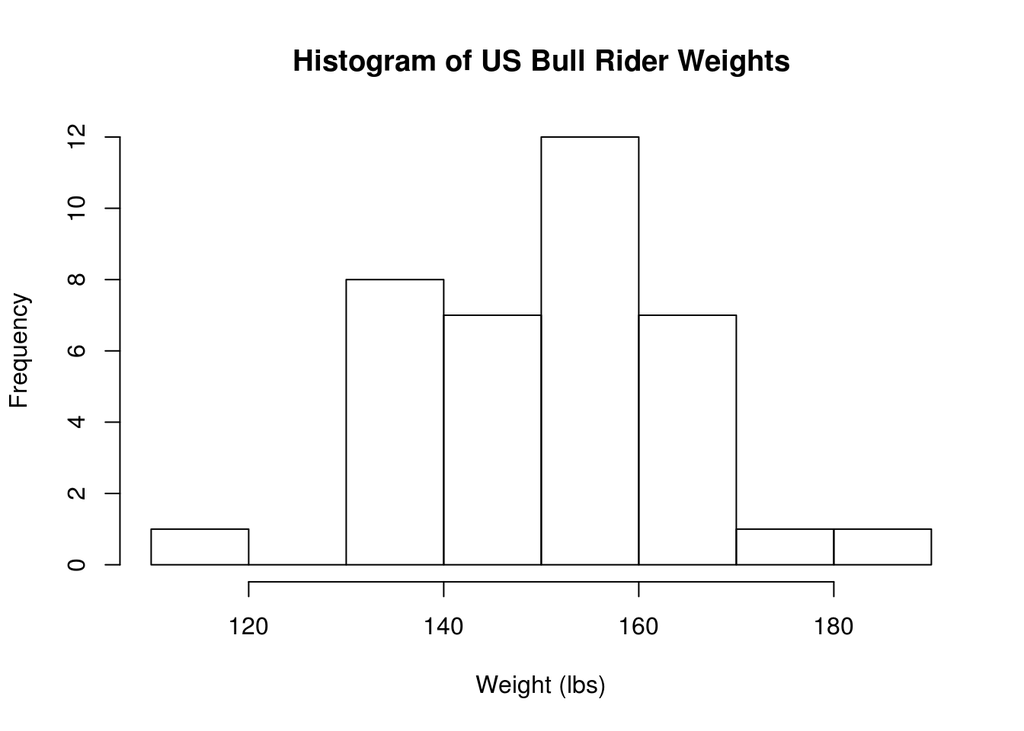

```r
# Visualize the weight distribution
hist(USA$Weight, main='Histogram of US Bull Rider Weights',xlab='Weight (lbs)')
```

```r
# Run the single sample t-test
t.test(USA$Weight, mu=190)
```

```
##
##  One Sample t-test
##
## data:  USA$Weight
## t = -17.231, df = 36, p-value < 2.2e-16
## alternative hypothesis: true mean is not equal to 190
## 95 percent confidence interval:
##  148.7660 157.4502
## sample estimates:
## mean of x
##  153.1081
```

problem 1/1 point (graded) 1. What type of graph are we going to use to visualize the weights of the bull-riders?

histogram correct scatterplot boxplot Submit You have used 1 of 1 attempt Some problems have options such as save, reset, hints, or show answer. These options follow the Submit button.

Show Answer Correct (1/1 point) Review problem 1/1 point (graded) 2. What portion of the code defines the value of the null hypothesis?

mu=190 correct `mean(USA$Weight)` t.test Submit You have used 1 of 1 attempt Some problems have options such as save, reset, hints, or show answer. These options follow the Submit button.

Show Answer Correct (1/1 point) Review problem 1/1 point (graded) 3. Which assumption can we confirm with the use of the following line of code: `hist(USA$Weight, main='Histogram of US Bull Rider Weights',xlab='Weight (lbs)')`

random sample Normality correct linearity independent observations Submit You have used 1 of 1 attempt Some problems have options such as save, reset, hints, or show answer. These options follow the Submit button.

Show Answer Correct (1/1 point) Review problem 1/1 point (graded) 4. If you wanted to calculate the standard error for this sample of 37 riders, what additional line of code would you need to add?

`mean(USA$Weight)/sqrt(37)` `sd(USA$Weight)/sqrt(37)` correct `SE <- t.test(USA$Weight)` Submit You have used 1 of 1 attempt Some problems have options such as save, reset, hints, or show answer. These options follow the Submit button.

Show Answer Correct (1/1 point) Review problem 1/1 point (graded) 5. What is the cause of the error in the code below?

bull <- BullRiders `hist(bull$YearBorn, main = 'Histogram of Bull Rider Weights, xlab= 'Weight (lbs)')`

Error: unexpected symbol in “hist(bull$YearBorn, main = ’Histogram of Bull Rider Weights, xlab= ’Weight”

The “YearBorn” variable is spelled differently in our dataset. We cannot have parentheses around lbs in the histogram statement. We forgot to create a label for the y-axis. We used too few quotation marks in the histogram statement. correct

Primary Research Question

The average American adult man weighs 190 pounds. Do professional bull riders in the US weigh the same?

Conduct the Analysis in R

1. Type or copy the script from the the Prepare for the Analysis section into the Script window of R.
2. Select the portion of the code you wish to run, then press “ctrl+ enter.”
3. Output can be found in the Console window.

```r
#Select bull riders from the US
USA <-bull[bull$Country=="USA",]

# Summarize the bull rider weights
mean(USA$Weight)
```

```
## [1] 153.1081
```

```r
sd(USA$Weight)
```

```
## [1] 13.02302
```

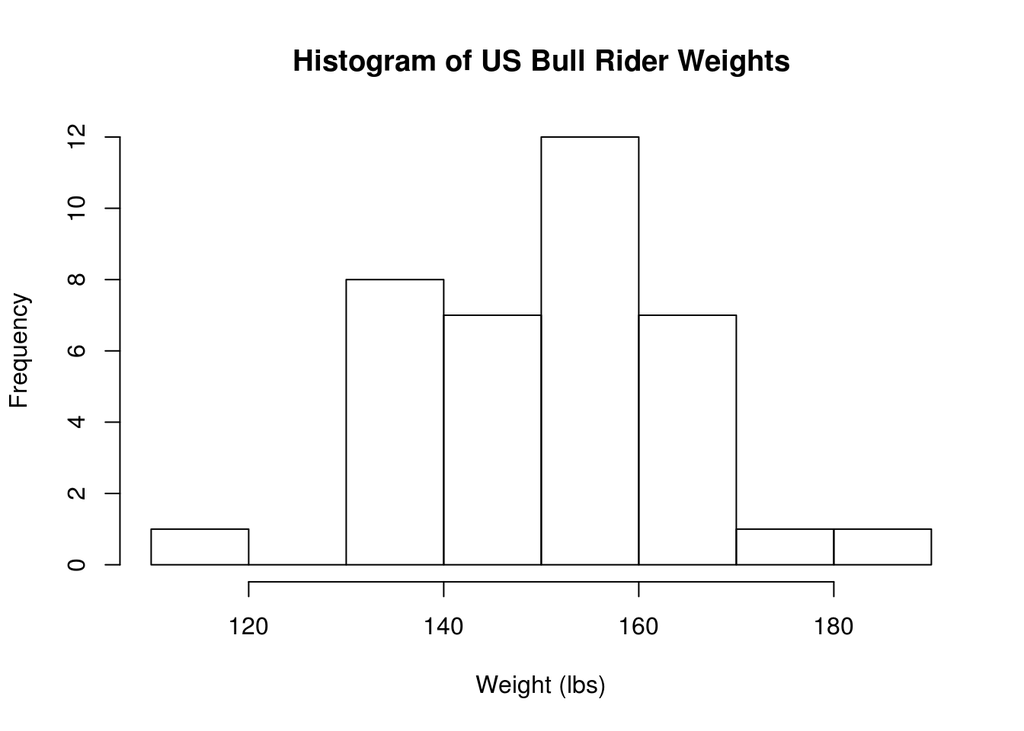

```r
# Visualize the weight distribution
hist(USA$Weight, main='Histogram of US Bull Rider Weights',xlab='Weight (lbs)')
```

```r
# Run the single sample t-test
t.test(USA$Weight, mu=190)
```

```
##
##  One Sample t-test
##
## data:  USA$Weight
## t = -17.231, df = 36, p-value < 2.2e-16
## alternative hypothesis: true mean is not equal to 190
## 95 percent confidence interval:
##  148.7660 157.4502
## sample estimates:
## mean of x
##  153.1081
```

problem 1/1 point (graded) 1. Did the histogram of the bull-riders’ weights show any significant skew that would violate the assumption of Normality?

Yes No correct Submit You have used 1 of 1 attempt Some problems have options such as save, reset, hints, or show answer. These options follow the Submit button.

Show Answer Correct (1/1 point) Review problem 2/2 points (graded) Report the sample statistics for the bull-rider weights. (Round to 2 decimal places.)

2a. Sample mean (in pounds)=

153.11 correct 153.11 2b. Sample standard deviation (in pounds)=

13.02 correct 13.02 Submit You have used 1 of 1 attempt Some problems have options such as save, reset, hints, or show answer. These options follow the Submit button.

Show Answer Correct (2/2 points) Review problem 4/4 points (graded) One-sample t test results:

3a. t-statistic (rounded to 1 decimal place) =

-17.2 correct −17.2 3b. degrees of freedom for the test =

36 correct 36 95% confidence interval:

3c. Lower bound estimate, in pounds (rounded to 1 decimal place) =

148.8 correct 148.8 3d. Upper bound estimate, in pounds (rounded to 1 decimal place) =

157.5 correct 157.5 Submit You have used 1 of 1 attempt Some problems have options such as save, reset, hints, or show answer. These options follow the Submit button.

Show Answer Correct (4/4 points) Review problem 1/1 point (graded) 4. The p-value of the test was very small (< 0.05). How should we interpret this p-value?

If bull-riders really do weigh 190 pounds on average, observing this sample mean is very unlikely. correct We can only be 5% certain with our results; this test was inconclusive. The percent of bull-riders weighing 190 pounds is less than 5%. There is a 5% chance that bull-riders weigh 190 pounds on average. Submit You have used 1 of 1 attempt Some problems have options such as save, reset, hints, or show answer. These options follow the Submit button.

Show Answer Correct (1/1 point) Review problem 2/2 points (graded) We should ________ the hypothesis that the mean weight of bull riders is equal to 190 lbs. It appears that the bull-riders actually weigh ________ than the average American man.

5a.

correctreject 5b.

correctless

Primary Research Question

The average American adult male weighs 190 pounds. Do professional bull-riders in the US weigh the same?

problem 6/6 points (graded) Write Your Conclusion

Answer the question and support your answer with statistics:

The distribution of weight for this sample of professional bull riders is correctapproximately Normal with a mean of 153.11 lbs and a correctstandard deviation of 13.02 lbs. We found that their mean weight correctis significantly different than 190 lbs, with t= -17.2, p correctless than 0.05. We are correct95% confident that the true mean of professional bull riders is between 148.8 lbs and 157.5 lbs, suggesting that professional bull riders weigh correctless than the average adult male.

# Lab 2: Bull Rider Data

[figure not shown]

Over 1,200 bull riders from around the world are members of Professional Bull Riders (PBR) and compete in the more than 300 PBR affiliated bull riding events per year. This data set includes information about the top 50 ranked bull riders for the 2013, according to the PBR standings reported in July of 2013. Rankings are based on a system which awards points for qualified rides at events throughout the season.

problem 2/2 points (graded) Review of the One-Sample t-Test

In this lab, you will use a one-sample t-test to answer a question of interest. Let’s start by remembering why we use hypothesis tests.

1a. What is the goal of a hypothesis test?

To explain a causal relationship, such as “What makes that particular bull harder to ride?” To identify what the true value of a population mean is, based on the sample mean. To determine if the sample data is consistent, or inconsistent, with the null hypothesis about the population. correct To prove that the alternative hypothesis is true. 1b. For your test result to be considered trustworthy, your data must meet the assumptions for a one-sample t-test. Which of the following is not an assumption of this test?

The data was collected voluntarily from all subjects. correct The sample is made up of independent observations. The population distribution should be nearly Normal, or the sample should be large. A random sample is used. Submit You have used 1 of 1 attempt Some problems have options such as save, reset, hints, or show answer. These options follow the Submit button.

Show Answer Correct (2/2 points) Review problem 1/1 point (graded) Lab Preparation

In this lab you will be working with data from the Professional Bull Riders Association.

1. Open RStudio. Make sure you’ve installed the SDSFoundations package.
2. Type library(SDSFoundations). This will automatically load the data for the labs. 3.Type bull <- BullRiders. This will assign the data to your Workspace.

Alternatively, you can use follow the steps in the “Importing a Data Frame” R tutorial video, and use the BullRiders.csv file. (Right-click and “Save As.”) Make sure to name the dataframe “bull” when importing.

1. Open RStudio.
2. Click on “Import Dataset” button at the top of the workspace window. Choose “from text file.”
3. Click on the location of the BullRiders.csv file you just downloaded.
4. Click on the BullRiders.csv file. Then, click Upload.

Feel free to use the script from the week’s PreLab, which you can modify for use in this Lab.

2. One of the following questions will be answered in this lab using a one-sample t-test. Select the question that can be answered with this method.

Is there a difference in number of buck-offs for riders with and without event wins? Is the average ride percentage of professional bull riders at least 50%? correct Do professional bull riders with more cup points earn more money? Do older professional bull riders have a higher ride percentage than younger riders?

Primary Research Question

Do professional bull riders stay on their bulls 50% of the time? Test the hypothesis that the mean ride percentage is 0.500 in 2014, using riders with at least 5 events in 2014.

Analysis

Let’s break this question down into the different descriptive statistics that you will need to construct your answer. Be sure that your R output includes all of the following components.

1. Select the riders that participated in at least 5 events in 2014.
2. Calculate the sample mean and standard deviation of ride percentage in 2014.
3. Generate a histogram to look at the distribution of the ride percentage in 2014.
4. Confirm the assumptions of a one-sample t-test.
5. Run the t-test and interpret the results.

```r
riders5_2014 <- bull[bull$Events14 >= 5, ]

print("Mean:")
```

```
## [1] "Mean:"
```

```r
mean(riders5_2014$RidePer14)
```

```
## [1] 0.3346643
```

```r
print("SD:")
```

```
## [1] "SD:"
```

```r
sd(riders5_2014$RidePer14)
```

```
## [1] 0.1065763
```

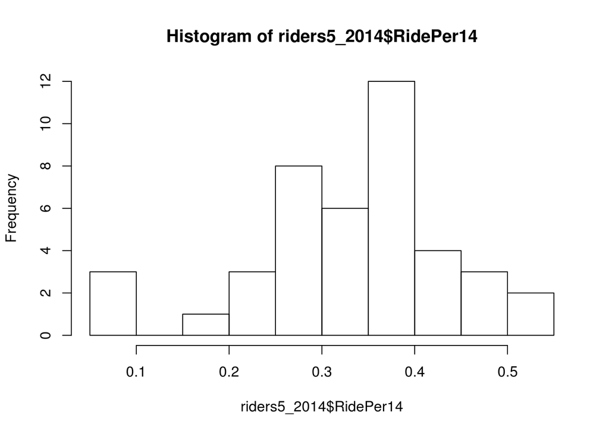

```r
hist(riders5_2014$RidePer14)
```

```r
t.test(riders5_2014$RidePer14, mu = 0.5)
```

```
##
##  One Sample t-test
##
## data:  riders5_2014$RidePer14
## t = -10.054, df = 41, p-value = 1.253e-12
## alternative hypothesis: true mean is not equal to 0.5
## 95 percent confidence interval:
##  0.3014528 0.3678758
## sample estimates:
## mean of x
## 0.3346643
```

Primary Research Question

Do professional bull riders stay on their bulls 50% of the time? Test the hypothesis that the mean ride percentage is 0.500 in 2014, using riders with at least 5 events in 2014.

Analysis

Let’s break this question down into the different descriptive statistics that you will need to construct your answer. Be sure that your R output includes all of the following components.

1. Select the riders that participated in at least 5 events in 2014.
2. Calculate the sample mean and standard deviation of ride percentage in 2014.
3. Generate a histogram to look at the distribution of the ride percentage in 2014.
4. Confirm the assumptions of a one-sample t-test.
5. Run the t-test and interpret the results.

problem 2/2 points (graded) Descriptive Statistics

1a. What was the average ride percentage in 2014 for this sample? (Round to 3 decimal places.)

0.335 correct 0.335 1b. What was the standard deviation of ride percentage in 2014 for this sample? (Round to 3 decimal places.)

0.107 correct 0.107 Submit You have used 1 of 1 attempt Some problems have options such as save, reset, hints, or show answer. These options follow the Submit button.

Show Answer Correct (2/2 points) Review problem 2/3 points (graded) Test Statistics

2a. What is the value of the t-statistic? (Round absolute value to 2 decimal places.)

-10.05 incorrect10.05 −10.05 2b. How many degrees of freedom?

41 correct41 41 2c. The p-value was _______ 0.001.

correctless than Submit You have used 1 of 1 attempt Some problems have options such as save, reset, hints, or show answer. These options follow the Submit button.

Show Answer Answers are displayed within the problem Review problem 1/1 point (graded) 3. What decision should you reach, based on these test results?

fail to reject the null hypothesis reject the null hypothesis correct Submit You have used 1 of 1 attempt Some problems have options such as save, reset, hints, or show answer. These options follow the Submit button.

Show Answer Correct (1/1 point) Review problem 1/1 point (graded) What is the appropriate conclusion for this test? Professional bull riders do stay on their bulls 50% of the time. Professional bull riders do not stay on their bulls 50% of the time. correct

Primary Research Question

Do professional bull riders stay on their bulls 50% of the time? Test the hypothesis that the mean ride percentage is 50%.

problem 8/8 points (graded) Write Your Conclusion

Answer the question and support your answer with statistics:

The distribution of the percentage of time a professional bull rider stays on the bull for this sample is correctapproximately normal , with a mean of correct33.50% , and a correctstandard deviation of 10.7%. We found that their mean ride percentage correctis significantly different from 50%, with t= correct-10.05 , p<0.05. We are correct95% confident that the true mean of ride percentage of professional bull riders is between correct30.1% and correct36.8% suggesting that professional bull riders ride the full 8 seconds about 1/3 of the time. Submit

## Problem Set

Question 1

How much money do professional bull riders earn by participating in an event?

1. Create a new variable that equals the “average earnings per event” in the 2012 season for each bull rider in the dataset. Call this new variable “earnings_per”
2. Make a histogram of your “earnings per event” variable.
3. Use this data to answer the following questions.

Use the “BullRiders.csv” dataset to answer the following questions. Instructions for installing “BullRiders.csv” can be found under the Examine the Data unit in this week’s Pre-Lab section.

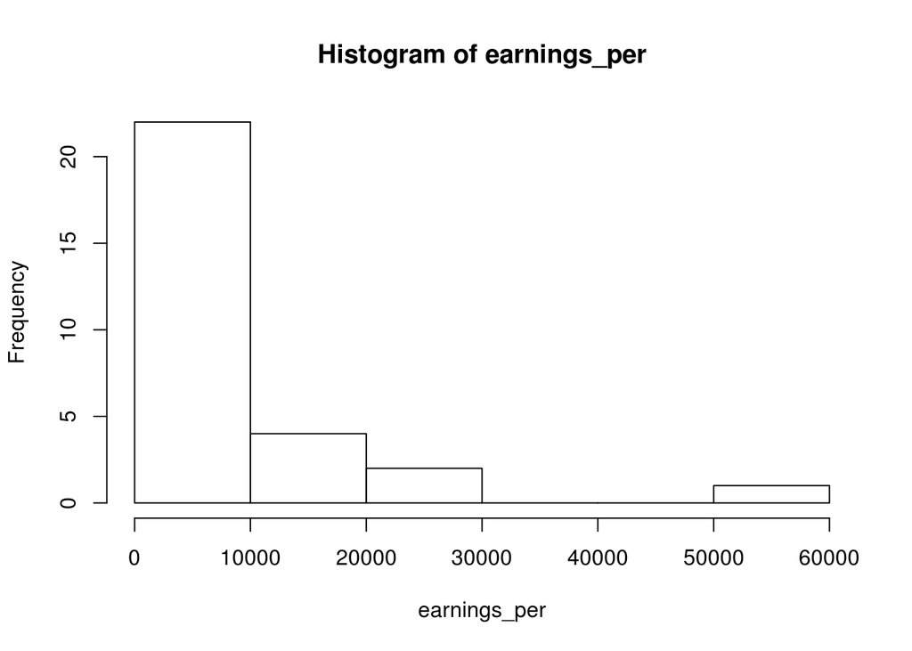

```r
earnings_per <- bull$Earnings12 / bull$Events12
hist(earnings_per)
```

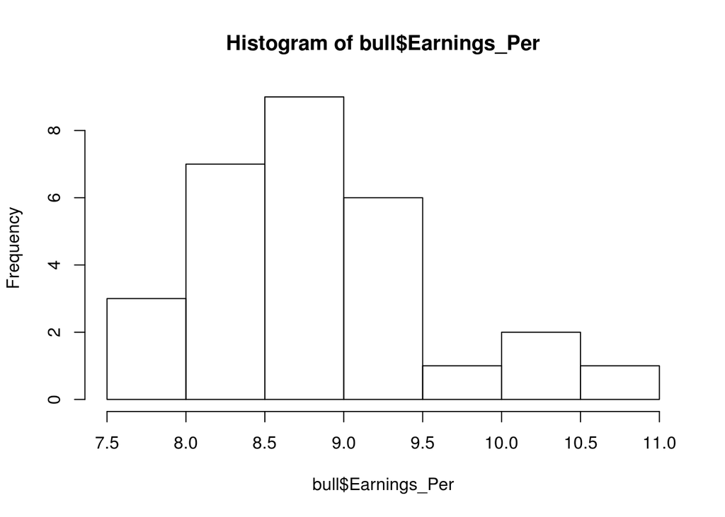

```r
bull$Earnings_Per <- log(earnings_per)
hist(bull$Earnings_Per)
```

```r
mean(bull$Earnings_Per, na.rm = TRUE)
```

```
## [1] 8.846387
```

```r
sd(bull$Earnings_Per, na.rm = TRUE)
```

```
## [1] 0.7209062
```

```r
t.test(bull$Earnings_Per)
```

```
##
##  One Sample t-test
##
## data:  bull$Earnings_Per
## t = 66.082, df = 28, p-value < 2.2e-16
## alternative hypothesis: true mean is not equal to 0
## 95 percent confidence interval:
##  8.572169 9.120605
## sample estimates:
## mean of x
##  8.846387
```

```r
exp(8.572169)
```

```
## [1] 5282.575
```

```r
exp(9.120605)
```

```
## [1] 9141.731
```

problem 0/1 point (graded) 1a. Have we met the assumptions for being able to calculate a 95% confidence interval to estimate the true mean earnings-per-event for a professional bull rider (using t)? Use the histogram to help answer this question.

Yes, the distribution of “earnings_per” looks realively normal No, the distribution of “earnings_per” is positively skewed, with an outlier correct No, the distribution of “earnings_per” is negatively skewed, with an outlier incorrect No, the distribution of “earnings_per” looks realively normal, but contains outliers Submit You have used 1 of 1 attempt Some problems have options such as save, reset, hints, or show answer. These options follow the Submit button.

Show Answer Answers are displayed within the problem Review When a variable is highly skewed, we can transform the data into a shape that allows us to conduct our analysis.

1. Create a new variable that is the log of your “earnings_per” variable.
2. Here is the code to make a log transformation of a variable:

bull$newvariable <- log(bull$originalvariable)

3. Now use this new variable to answer the following questions.

problem 1/1 point (graded) 1b. Make a histogram of this log-transformed variable. Notice how the distribution shape has changed. Can we reliably calculate a 95% confidence interval for the mean of this transformed variable?

Yes, the distributuon of the log-transformed variable looks relatively normal (some slight positive skew). correct No, the distributuon of the log-transformed variable still shows severe positive skew. No, the distributuon of the log-transformed variable is negatively skewed. No, the distributuon of the log-transformed variable has many outliers. Submit You have used 1 of 1 attempt Some problems have options such as save, reset, hints, or show answer. These options follow the Submit button.

Show Answer Correct (1/1 point) Review problem 1/1 point (graded) 1c. What is the mean of the log-transformed earnings-per-event variable? (Round to 2 decimal places.)

8.85 correct 8.85 Submit You have used 1 of 1 attempt Some problems have options such as save, reset, hints, or show answer. These options follow the Submit button.

Show Answer Correct (1/1 point) Review problem 1/1 point (graded) 1d. What are the lower and upper-bounds for a 95% confidence interval around this transformed mean? (Round each to 2 decimal places.)

Lower-bound

8.57 correct 8.57 Submit You have used 1 of 1 attempt Some problems have options such as save, reset, hints, or show answer. These options follow the Submit button.

Show Answer Correct (1/1 point) Review problem 1/1 point (graded) Upper-bound(Round to 2 decimal places.)

9.12 correct 9.12 Submit You have used 1 of 1 attempt Some problems have options such as save, reset, hints, or show answer. These options follow the Submit button.

Show Answer Correct (1/1 point) Review To best interpret the 95% confidence interval, we need to transform the lower and upper bound estimates back into dollars/events.

1. Here is the code you will use to take a log-transformed value back to the original units:

exp(lowerboundvalue)

exp(upperboundvalue)

2. Run this code on the unrounded original values. Then answer the questions that follow.

problem 0/1 point (graded) 1e. What are the lower and upper-bounds for a 95% confidence interval in dollars/event units. (Round each to whole numbers with no decimal places.)

Lower-bound

5271 incorrect5283 5271 Submit You have used 1 of 1 attempt Some problems have options such as save, reset, hints, or show answer. These options follow the Submit button.

Show Answer Answers are displayed within the problem Review problem 0/1 point (graded) Upper-bound(Round to whole number with no decimal places.)

9136 incorrect9142 9136

Question 2

Students collected 8 random bags of a specific brand of potato chips and carefully weighed the contents of each bag, recording the following weights (in grams):

29.4 29.0 28.4 28.8 28.9 29.3 28.5 28.2

The students want to test the claim that the mean weight of these bags is 28.5 grams. They think it may be different.

```r
chips <- c(29.4, 29.0, 28.4, 28.8, 28.9, 29.3, 28.5, 28.2)
mean(chips)
```

```
## [1] 28.8125
```

```r
sd(chips)
```

```
## [1] 0.4257347
```

```r
t.test(chips)
```

```
##
##  One Sample t-test
##
## data:  chips
## t = 191.42, df = 7, p-value = 2.803e-14
## alternative hypothesis: true mean is not equal to 0
## 95 percent confidence interval:
##  28.45658 29.16842
## sample estimates:
## mean of x
##   28.8125
```

Question 2

Students collected 8 random bags of a specific brand of potato chips and carefully weighed the contents of each bag, recording the following weights (in grams):

29.4 29.0 28.4 28.8 28.9 29.3 28.5 28.2

The students want to test the claim that the mean weight of these bags is 28.5 grams. They think it may be different.

problem 1/1 point (graded) 2a. What is the appropriate null hypotheses for this test?

H0: 𝜇 > 28.5 H0: 𝜇 = 28.5 correct H0: 𝜇 = 0 H0: 𝜇 = 28.5 - 0 Submit You have used 1 of 1 attempt Some problems have options such as save, reset, hints, or show answer. These options follow the Submit button.

Show Answer Correct (1/1 point) Review problem 1/1 point (graded) 2b. What are the sample mean and standard deviation? (Round each to 2 decimal places.)

Mean

28.81 correct 28.81 Submit You have used 1 of 1 attempt Some problems have options such as save, reset, hints, or show answer. These options follow the Submit button.

Show Answer Correct (1/1 point) Review problem 1/1 point (graded) Standard Deviation(Round to 2 decimal places.)

0.43 correct 0.43 Submit You have used 1 of 1 attempt Some problems have options such as save, reset, hints, or show answer. These options follow the Submit button.

Show Answer Correct (1/1 point) Review problem 1/1 point (graded) 2c. What is the test statistic for this hypothesis test? This is the t-statistic for the sample mean. (Round to 2 decimal places.)

NOTE: Be sure to use the proper formula and your rounded answers to the previous questions to determine the statistic. If you use R or do not use the rounded values, your answer may be marked incorrect.

2.04 correct 2.04 Submit You have used 1 of 1 attempt Some problems have options such as save, reset, hints, or show answer. These options follow the Submit button.

Show Answer Correct (1/1 point) Review problem 0/1 point (graded) 2d. What is t-critical for this test, assuming an alpha level of 0.05? (Round to 3 decimal places.)

1.895 incorrect2.365 1.895 Submit You have used 1 of 1 attempt Some problems have options such as save, reset, hints, or show answer. These options follow the Submit button.

Show Answer Answers are displayed within the problem Review problem 0/1 point (graded) 2e. What was the outcome of your test?

Confirm the null hypothesis p>0.05 Reject the null hypothesis p<0.05 Fail to reject the null hypothesis p>0.05 correct Fail to reject the null hypothesis p<0.05 incorrect Submit You have used 1 of 1 attempt Some problems have options such as save, reset, hints, or show answer. These options follow the Submit button.

Show Answer Answers are displayed within the problem Review problem 0/1 point (graded) 2f. In addition to random selection, what other condition of the data must be true for our t-test outcome to be reliable?

The bags of potato chips must have an approximately Normal population distribution for weight. correct The bags of potato chips must have an approximately Normal sample distribution for weight. incorrect The bags of potato chips must come from the same manufacturer. Each bag must be related to every other bag in the sample. Submit You have used 1 of 1 attempt Some problems have options such as save, reset, hints, or show answer. These options follow the Submit button.

Show Answer Answers are displayed within the problem Review problem 1/1 point (graded) 2g. Does your data provide sufficient evidence to suggest that the mean weight of these bags of potato chips is not 28.5 g per bag?

Yes No correct

Question 3

An industrial plant dumps its waste into a nearby river, but claims that it is not impacting the native species of frogs that live in the river. The frogs are able to tolerate calcium concentrations up to 91 mg/L.

You measure the concentration of calcium in 25 random samples from the river. Your measurements are approximately normally distributed, with a mean of 93.6 mg/L, with a standard deviation of 7.8 mg/L.

problem 0/1 point (graded) 4a. What is t-critical for a 90% confidence interval? (Report as a positive value rounded to 3 decimal places.)

1.363 incorrect1.796 1.363 Submit You have used 1 of 1 attempt Some problems have options such as save, reset, hints, or show answer. These options follow the Submit button.

Lower-bound

39.85 correct 39.85 Submit You have used 1 of 1 attempt Some problems have options such as save, reset, hints, or show answer. These options follow the Submit button.

Show Answer Correct (1/1 point) Review problem 1/1 point (graded) Upper-bound(Round to 2 decimal places.)

45.35 correct 45.35 Submit You have used 1 of 1 attempt Some problems have options such as save, reset, hints, or show answer. These options follow the Submit button.

Show Answer Correct (1/1 point) Review problem 0/1 point (graded) 4c. If you calculated a 95% confidence interval for the population mean from the same data, would your confidence interval be narrower or wider than your interval above?

Narrower incorrect Wider correct